# Colombo Amenity Distribution: Point Pattern Analysis & Spatial Regression

- Show All Code
- Hide All Code
- View Source

Author

Nimesh Akalanka

Published

February 26, 2026

# 1 Data Loading & Preparation

These steps include the preparation of spatial data for the analysis of Colombo District. The task involves loading relevant datasets, converting the coordinate system to EPSG:32644 for proper dimension and area calculations, and merging demographic data with building information. The goal is to calculate attributes related to population demographics, housing, road infrastructure, and building area.

- **Population Groups:**
  - `Population_0_14`: Number of people aged 0-14.
  - `Population_15_59`: Number of people aged 15-59.
  - `Population_60_64`: Number of people aged 60-64.
  - `Population_Above_65`: Number of people aged above 65.
  - `Male`: Total number of males.
  - `Female`: Total number of females.
  - `Total_Population`: Total number of people (Male + Female).
- **Housing and Employment:**
  - `Occupied_Housing_Units`: Number of occupied housing units.
  - `Poverty_Percentage`: Percentage of the population living in poverty.
  - `Unemployment_Rate`: Unemployment rate in the area.
- **Infrastructure:**
  - `Road_Density`: Density of roads in the area.
  - `Road_Length`: Total length of roads in the area.
- **Geospatial Calculations:**
  - `Population_Density`: Population density per square kilometer.
  - `Building_Area`: Area of buildings (units: square meters)

Furthermore all the datasets are clipped in to the Colombo district boundary to ensure that the analysis is focused on the relevant geographic area.

```r
# Load necessary libraries
library(sf)
library(dplyr)
library(tidyr)
library(ggplot2)
library(tmap)
library(terra)
library(spatstat)
library(spdep)
library(spatialreg)
library(knitr)
library(kableExtra)
library(patchwork)

# Improve figure clarity in rendered output
knitr::opts_chunk$set(
  fig.align = "center",
  fig.width = 9,
  fig.height = 6,
  dpi = 180,
  out.width = "100%"
)

# Select an projected coordinate system and set up the output directory
utm_crs <- 32644
output_dir <- "output"
dir.create(output_dir, recursive = TRUE, showWarnings = FALSE)
gpkg_path <- file.path(output_dir, "output_layers.gpkg")

# Load Sri Lankan GND boundaries
sl_gnds <- st_read("data/sl_gnds.shp", quiet = TRUE) %>%
  st_make_valid() %>%
  st_transform(utm_crs)

# Consider only Colombo district for this analysis
names(sl_gnds)
```

```
[1] "PROVINCE_N" "DISTRICT_N" "DSD_N"      "GND_N"      "geometry"
```

```r
unique(sl_gnds$DISTRICT_N)
```

```
 [1] "Kandy"        "Matale"       "Nuwara Eliya" "Ampara"       "Batticaloa"
 [6] "Trincomalee"  "Anuradhapura" "Polonnaruwa"  "Kurunegala"   "Puttalam"
[11] "Jaffna"       "Kilinochchi"  "Mannar"       "Mullaitivu"   "Vavuniya"
[16] "Kegalle"      "Ratnapura"    "Galle"        "Hambantota"   "Matara"
[21] "Badulla"      "Moneragala"   "Colombo"      "Gampaha"      "Kalutara"
```

```r
cmb_gnds <- sl_gnds %>% filter(DISTRICT_N == "Colombo")
cmb_boundary <- st_union(cmb_gnds)

# Read the census population data from census csv file
cmb_census <- read.csv("data/cmb_census_2024.csv")

# Join the census population data to the Colombo GNDs
# Consider both the GND and DSD names
cmb_gnds <- cmb_gnds %>%
  mutate(
    GND_N = trimws(toupper(GND_N)),
    DSD_N = trimws(toupper(DSD_N))
  ) %>%
  left_join(
    cmb_census %>%
      mutate(
        GND_Name = trimws(toupper(GND_Name)),
        DSD_Name = trimws(toupper(DSD_Name)),
        AG_0_14 = as.numeric(gsub(",", "", trimws(AG_0_14))),
        AG_15_59 = as.numeric(gsub(",", "", trimws(AG_15_59))),
        AG_60_64 = as.numeric(gsub(",", "", trimws(AG_60_64))),
        AG_65_and_above = as.numeric(gsub(",", "", trimws(AG_65_and_above))),
        Male = as.numeric(gsub(",", "", trimws(Male))),
        Female = as.numeric(gsub(",", "", trimws(Female))),
        Total = as.numeric(gsub(",", "", trimws(Total))),
        Occupied_Housing_Units = as.numeric(gsub(",", "", trimws(Occupied_Housing_Units))),
        Poverty_Percentage = as.numeric(gsub(",", "", trimws(Poverty_Percentage))),
        Unemployment_Rate = as.numeric(gsub(",", "", trimws(Unemployment_Rate))),
        Road_Density = as.numeric(gsub(",", "", trimws(Road_Density))),
        Road_Length = as.numeric(gsub(",", "", trimws(Road_Length)))
      ) %>%
      select(
        DSD_Name, GND_Name, AG_0_14, AG_15_59, AG_60_64, AG_65_and_above, Male, Female, Total,
        Occupied_Housing_Units, Poverty_Percentage, Unemployment_Rate, Road_Density, Road_Length
      ),
    by = c("DSD_N" = "DSD_Name", "GND_N" = "GND_Name")
  ) %>%
  mutate(
    GND_N = tools::toTitleCase(tolower(GND_N)),
    DSD_N = tools::toTitleCase(tolower(DSD_N)),
    Area_sqkm = as.numeric(st_area(geometry)) / 1e6,
    Pop_density_sqkm = Total / Area_sqkm
  )

# Check how many GNDs were successfully matched
cat("GNDs with population data:", sum(!is.na(cmb_gnds$Total)), "of", nrow(cmb_gnds), "\n")
```

```
GNDs with population data: 557 of 557
```

```r
# Load Sri Lankan Building footprints
cmb_build <- st_read("data/sl_buildings.shp", quiet = TRUE) %>%
  st_transform(utm_crs) %>%
  st_intersection(cmb_boundary)

# Calculate total building footprint area per GND (Unit: square meters)
building_area_by_gnd <- cmb_build %>%
  mutate(building_area = as.numeric(st_area(.))) %>%
  st_join(cmb_gnds %>% select(GND_N)) %>%
  st_drop_geometry() %>%
  group_by(GND_N) %>%
  summarise(Building_area = sum(building_area, na.rm = TRUE), .groups = "drop")

# Join building area back to cmb_gnds
cmb_gnds <- cmb_gnds %>%
  left_join(building_area_by_gnd, by = "GND_N") %>%
  mutate(Building_area = coalesce(Building_area, 0))

# Save the file to GeoPackage
st_write(cmb_build, gpkg_path, layer = "cmb_build", delete_layer = TRUE, quiet = TRUE)

# Show the information about the loaded buildings and POI data
cat("Number of GNDs loaded:", nrow(cmb_gnds), "\n")
```

```
Number of GNDs loaded: 557
```

In this study mainly 02 main amenity categories are considered in the OSM dataset under the fclass attribute:

- **Education Facilities:**
  - `school`
  - `university`
  - `college`
  - `kindergarten`
- **Healthcare Facilites:**
  - `hospital`
  - `clinic`
  - `pharmacy`
  - `doctors`
  - `dentist`
  - `veterinary`
  - `nursing_home`

Then other POI categories are filtered out and only the above two categories are retained for the analysis.

```r
# Import Colombo POI data as points
cmb_poi <- st_read("data/sl_pois.shp", quiet = TRUE) %>%
  st_transform(utm_crs) %>%
  st_intersection(cmb_boundary)

# Inspect the POI attribute names
print(names(cmb_poi))
```

```
[1] "osm_id"   "code"     "fclass"   "name"     "geometry"
```

```r
# Classify POIs based on fclass
cmb_poi <- cmb_poi %>%
  mutate(
    amenity_type = case_when(
      fclass %in% c("school", "university", "college", "kindergarten") ~ "education",
      fclass %in% c("hospital", "clinic", "pharmacy", "doctors", "dentist", "veterinary", "nursing_home") ~ "healthcare",
      TRUE ~ NA_character_
    )) %>% filter(!is.na(amenity_type))

# Perform a spatial join to associate GND_N with POIs
cmb_poi_with_gnd <- st_join(cmb_poi, cmb_gnds %>% select(GND_N))

# Check if the GND_N is correctly added to the POI data
print(names(cmb_poi_with_gnd))
```

```
[1] "osm_id"       "code"         "fclass"       "name"         "amenity_type"
[6] "GND_N"        "geometry"
```

```r
head(cmb_poi_with_gnd)
```

```
Simple feature collection with 6 features and 6 fields
Geometry type: POINT
Dimension:     XY
Bounding box:  xmin: 374626.5 ymin: 750124.3 xmax: 386507 ymax: 762313.2
Projected CRS: WGS 84 / UTM zone 44N
     osm_id code     fclass                                  name amenity_type
1 191815840 2110   hospital               Asiri Surgical Hospital   healthcare
2 253022237 2110   hospital       Joseph Fraser Memorial Hospital   healthcare
3 254367261 2110   hospital             Wethara District Hospital   healthcare
4 255179653 2110   hospital Sri Jayawardenapura teaching hospital   healthcare
5 255670316 2081 university     University of Sri Jayewardenepura    education
6 256542591 2082     school   Somaweera Chandrasiri Junior School    education
                GND_N                  geometry
1         Narahenpita POINT (376228.3 762236.9)
2     Thimbirigasyaya POINT (374626.5 762313.2)
3             Wethara   POINT (386507 750124.3)
4     Thalapathpitiya POINT (381352.6 759326.6)
5 Gangodavila South b   POINT (379121 757704.9)
6         Mampe North POINT (380988.8 752143.1)
```

```r
# Count education and healthcare POIs per GND
poi_counts_by_gnd <- cmb_poi_with_gnd %>%
  st_drop_geometry() %>%
  group_by(GND_N, amenity_type) %>%
  summarise(count = n(), .groups = "drop") %>%
  pivot_wider(names_from = amenity_type, values_from = count, values_fill = list(count = 0))


# Keep only final count columns for a stable join schema
poi_counts_by_gnd <- poi_counts_by_gnd %>%
  transmute(
    GND_N,
    education_count = as.integer(education),
    healthcare_count = as.integer(healthcare)
  )

# Check the resulting table
print(names(poi_counts_by_gnd))
```

```
[1] "GND_N"            "education_count"  "healthcare_count"
```

```r
print(head(poi_counts_by_gnd))
```

```
# A tibble: 6 × 3
  GND_N          education_count healthcare_count
  <chr>                    <int>            <int>
1 Akaravita                    1                0
2 Aluth Ambalama               1                0
3 Aluthkade East               2                0
4 Aluthmawatha                 5                1
5 Asiri Uyana                  0                4
6 Athurugiriya                 1                1
```

```r
# Join the counts back to cmb_gnds
cmb_gnds <- cmb_gnds %>%
  select(-any_of(c("education", "healthcare", "education_count", "healthcare_count"))) %>%
  left_join(poi_counts_by_gnd, by = "GND_N") %>%
  mutate(
    education_count = coalesce(education_count, 0L),
    healthcare_count = coalesce(healthcare_count, 0L)
  )

# Save the classified POIs to GeoPackage
st_write(cmb_poi, gpkg_path, layer = "cmb_poi", delete_layer = TRUE, quiet = TRUE)
st_write(cmb_gnds, gpkg_path, layer = "cmb_gnds", delete_layer = TRUE, quiet = TRUE)
```

# 2 Visualize the POI Distribution

Visualize the two amenity categories (educational and healthcare) across Colombo.

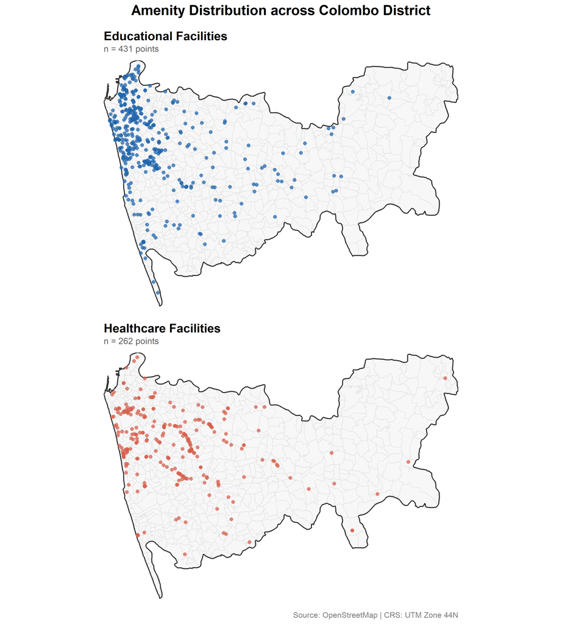

```r
# Split the data based on amenity categories
education <- cmb_poi %>% filter(amenity_type == "education")
healthcare <- cmb_poi %>% filter(amenity_type == "healthcare")

# Define a function to create maps
make_map <- function(pts, title, dot_color) {
  ggplot() +
    geom_sf(data = cmb_gnds, fill = "#f7f7f7", color = "#d9d9d9", linewidth = 0.25) +
    geom_sf(data = st_union(cmb_gnds), fill = NA, color = "#333333", linewidth = 0.6) +
    geom_sf(
      data  = pts,
      color = dot_color,
      size  = 1.7,
      alpha = 0.75,
      shape = 16
    ) +
    labs(
      title = title,
      subtitle = paste0("n = ", nrow(pts), " points")
    ) +
    theme_void(base_size = 12) +
    theme(
      plot.title      = element_text(
        face   = "bold",
        hjust  = 0,
        size   = 14,
        margin = margin(b = 3)
      ),
      plot.subtitle   = element_text(size = 10, color = "#5f5f5f", hjust = 0, margin = margin(b = 8)),
      plot.background = element_rect(fill = "white", color = NA),
      plot.margin     = margin(10, 10, 10, 10)
    ) +
    coord_sf(expand = FALSE)
}

# Plot the map
m1 <- make_map(education, "Educational Facilities", "#2166ac")
m2 <- make_map(healthcare,  "Healthcare Facilities",  "#d6604d")

m1 / m2 +
  plot_annotation(
    title   = "Amenity Distribution across Colombo District",
    caption = "Source: OpenStreetMap | CRS: UTM Zone 44N",
    theme   = theme(
      plot.title   = element_text(face = "bold", size = 16, hjust = 0.5),
      plot.caption = element_text(color = "grey50", size = 9, hjust = 1)
    )
  )
```

# 3 Amenity Distribution Analysis

Are the educational, healthcare facilities in Colombo distributed randomly, clustered or regularly distributed? Since spatstat requries a observation window, Colombo boundary is used as the observation window.

## 3.1 Quadrat Count Analysis

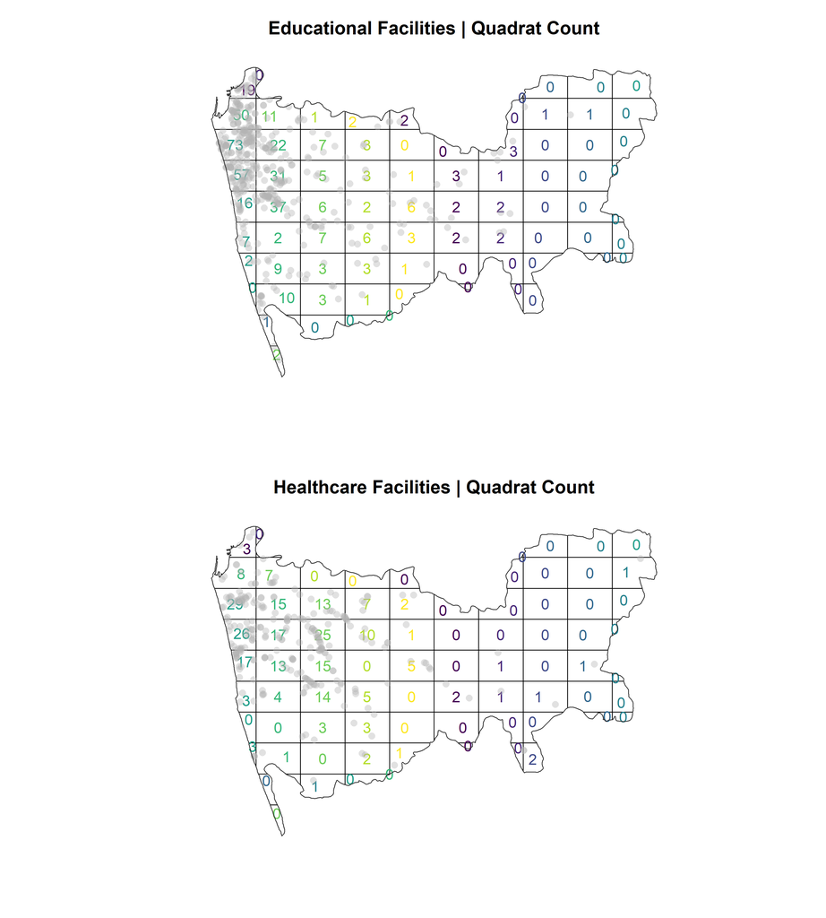

```r
library(viridis)
# Defining the observation window for the amenity categories
education_ppp <- as.ppp(education, W = as.owin(cmb_boundary))
healthcare_ppp <- as.ppp(healthcare, W = as.owin(cmb_boundary))

# Test the quadrant count for each amenity
education_quadrant <- quadratcount(education_ppp, nx = 10, ny = 10)
healthcare_quadrant <- quadratcount(healthcare_ppp, nx = 10, ny = 10)

# Plot the point distribution in the quardrants
op <- par(no.readonly = TRUE)
par(mfrow = c(2, 1), mar = c(3.8, 3.8, 3, 1.5), bg = "white")

plot(education_quadrant, main = "Educational Facilities | Quadrat Count", col = viridis(10), legend = TRUE, main.cex = 1.2)
plot(st_geometry(education), add = TRUE, col = adjustcolor("grey70", alpha.f = 0.4), pch = 16)
plot(as.owin(cmb_boundary), add = TRUE, border = "grey20", lwd = 1)

plot(healthcare_quadrant, main = "Healthcare Facilities | Quadrat Count", col = viridis(10),legend = TRUE, main.cex = 1.2)
plot(st_geometry(healthcare), add = TRUE, col = adjustcolor("grey70", alpha.f = 0.4), pch = 16)
plot(as.owin(cmb_boundary), add = TRUE, border = "grey20", lwd = 1)
```

```r
par(op)
```

## 3.2 Chi-squared Test for Complete Spatial Randomness (CSR)

Let’s do a chi-squared test to see if the observed distribution of amenities in the quadrants follow a complete spatial randomness (CSR) pattern or do they show clustering or regularity.

```r
# Test the quadrat counts for each amenity category
quadrat.test(education_quadrant)
```

```
    Chi-squared test of CSR using quadrat counts

data:
X2 = 2078.4, df = 77, p-value < 2.2e-16
alternative hypothesis: two.sided

Quadrats: 78 tiles (irregular windows)
```

p-value is less than 0.05 (if we consider a significance of 5%), reject the null hypothesis of complete spatial randomness (CSR) for educational facilities, indicating that they are not randomly distributed across Colombo. The observed distribution is likely to be clustered or regular. The magnitude of the test statistic constitute strong evidence against randomness, indicates an extremely uneven distribution, where educational facilities are heavily concentrated in a small number of quadrats while large portions of Colombo have very few or none at all. This points to significant spatial clustering of educational facilities across the district.

```r
# Test the quadrat counts for each amenity category
quadrat.test(healthcare_quadrant)
```

```
    Chi-squared test of CSR using quadrat counts

data:
X2 = 808.99, df = 77, p-value < 2.2e-16
alternative hypothesis: two.sided

Quadrats: 78 tiles (irregular windows)
```

The p-value is less than 0.05 (at a 5% significance level), we reject the null hypothesis of Complete Spatial Randomness (CSR) for healthcare facilities, indicating that they are not randomly distributed across Colombo. The observed distribution is likely to be clustered or regular. Although the test statistic (X² = 808.99) is considerably smaller than that of educational facilities, it still constitutes strong evidence against randomness, indicating an uneven distribution where healthcare facilities are concentrated in certain quadrats while other parts of Colombo remain comparatively underserved. This points to significant spatial clustering of healthcare facilities across the district.

## 3.3 Density Analysis

Perform a kernel density estimation to visualize the intensity of the given amenity categories see their visual differences in terms of spatial distribution across Colombo.

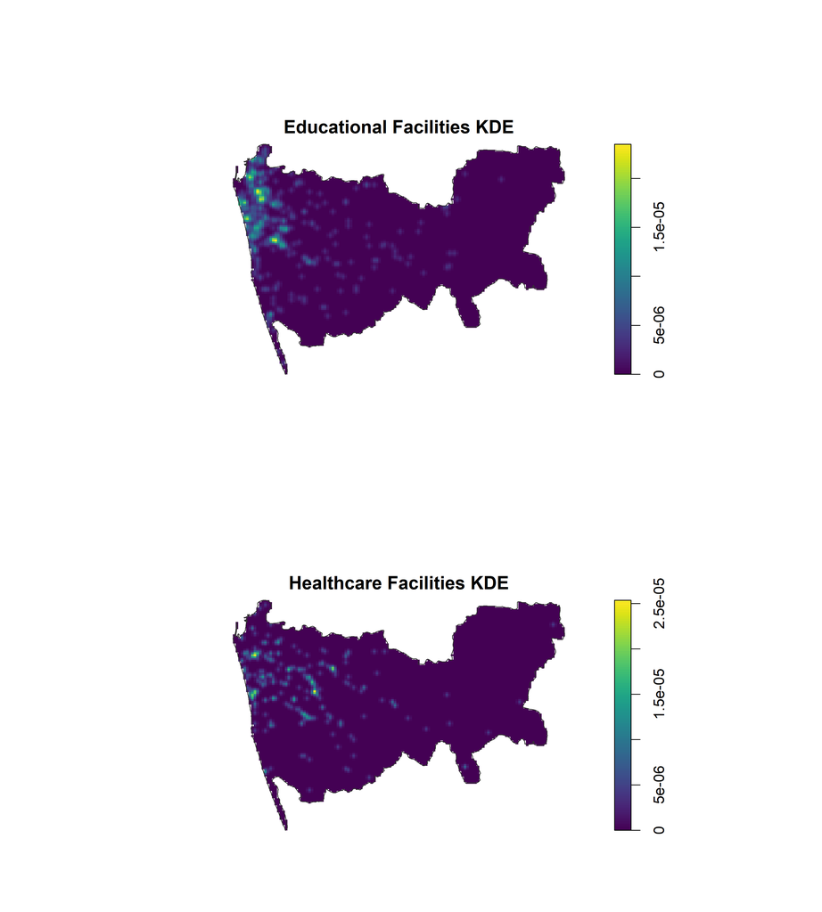

```r
# Calculate the kernel density
education_dens <- density(education_ppp, sigma = bw.diggle)
healthcare_dens <- density(healthcare_ppp, sigma = bw.diggle)

# Plot the kernel density
op <- par(no.readonly = TRUE)
par(mfrow = c(2, 1), mar = c(3.8, 3.8, 3, 1.5), bg = "white")

plot(education_dens, main = "Educational Facilities KDE", col = viridis(100))
plot(as.owin(cmb_boundary), add = TRUE, border = "grey20", lwd = 1)

plot(healthcare_dens, main = "Healthcare Facilities KDE", col = viridis(100))
plot(as.owin(cmb_boundary), add = TRUE, border = "grey20", lwd = 1)
```

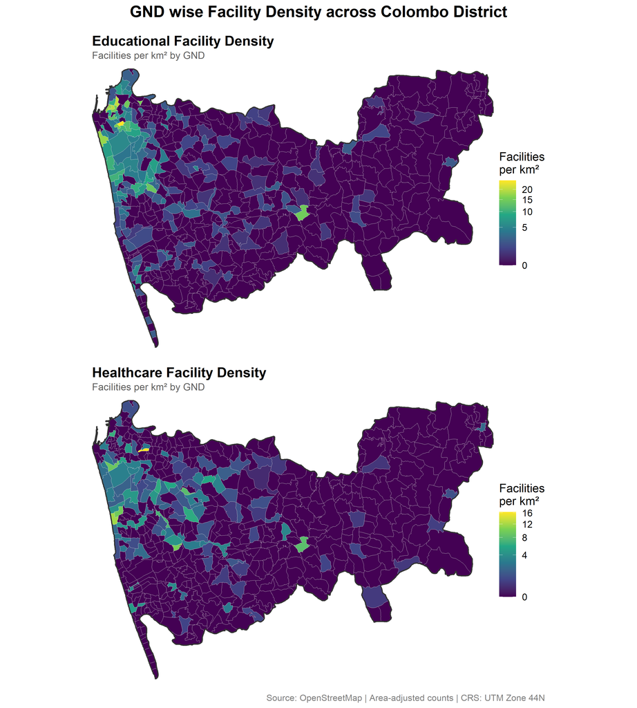

```r
par(op)

# Calculate facility density per km² for mapping
gnd_density <- cmb_gnds %>%
  st_as_sf() %>%
  mutate(
    education_density  = education_count  / Area_sqkm,
    healthcare_density = healthcare_count / Area_sqkm
  ) %>%
  select(GND_N, Area_sqkm, education_count, healthcare_count,
         education_density, healthcare_density, geometry)

# Plot the GND wise Density Map
p1 <- ggplot() +
  geom_sf(data = gnd_density, aes(fill = education_density),
          color = "#d9d9d9", linewidth = 0.15) +
  geom_sf(data = st_union(cmb_gnds), fill = NA,
          color = "#333333", linewidth = 0.6) +
  scale_fill_viridis_c(
    option    = "viridis",
    name      = "Facilities\nper km²",
    na.value  = "grey90",
    trans     = "sqrt"
  ) +
  labs(
    title    = "Educational Facility Density",
    subtitle = "Facilities per km² by GND"
  ) +
  theme_void(base_size = 12) +
  theme(
    plot.title      = element_text(face = "bold", size = 14, hjust = 0,
                                   margin = margin(b = 3)),
    plot.subtitle   = element_text(size = 10, color = "#5f5f5f", hjust = 0,
                                   margin = margin(b = 8)),
    plot.background = element_rect(fill = "white", color = NA),
    plot.margin     = margin(10, 10, 10, 10),
    legend.position = "right"
  ) +
  coord_sf(expand = FALSE)

p2 <- ggplot() +
  geom_sf(data = gnd_density, aes(fill = healthcare_density),
          color = "#d9d9d9", linewidth = 0.15) +
  geom_sf(data = st_union(cmb_gnds), fill = NA,
          color = "#333333", linewidth = 0.6) +
  scale_fill_viridis_c(
    option    = "viridis",
    name      = "Facilities\nper km²",
    na.value  = "grey90",
    trans     = "sqrt"
  ) +
  labs(
    title    = "Healthcare Facility Density",
    subtitle = "Facilities per km² by GND"
  ) +
  theme_void(base_size = 12) +
  theme(
    plot.title      = element_text(face = "bold", size = 14, hjust = 0,
                                   margin = margin(b = 3)),
    plot.subtitle   = element_text(size = 10, color = "#5f5f5f", hjust = 0,
                                   margin = margin(b = 8)),
    plot.background = element_rect(fill = "white", color = NA),
    plot.margin     = margin(10, 10, 10, 10),
    legend.position = "right"
  ) +
  coord_sf(expand = FALSE)

p1 / p2 +
  plot_annotation(
    title   = "GND wise Facility Density across Colombo District",
    caption = "Source: OpenStreetMap | Area-adjusted counts | CRS: UTM Zone 44N",
    theme   = theme(
      plot.title   = element_text(face = "bold", size = 16, hjust = 0.5),
      plot.caption = element_text(color = "grey50", size = 9, hjust = 1)
    )
  )
```

## 3.4 Selecting an Appropriate Correlation Method

Let’s see is the distribution of educational and healthcare facilities are similar accross Colombo district. First check that what type of distribution the KDE values of both categories follw.

```r
set.seed(13244)

# Convert spatstat density objects to terra rasters
education_rast  <- rast(education_dens)
healthcare_rast <- rast(healthcare_dens)

# Resample healthcare raster to match education raster grid exactly
healthcare_rast_resampled <- resample(healthcare_rast, education_rast)

# Extract raster cell values
education_vals  <- values(education_rast)
healthcare_vals <- values(healthcare_rast_resampled)

# Remove NA cells (cells outside the observation window)
valid <- !is.na(education_vals) & !is.na(healthcare_vals)
cat("Valid raster cells used:", sum(valid), "\n")
```

```
Valid raster cells used: 8968
```

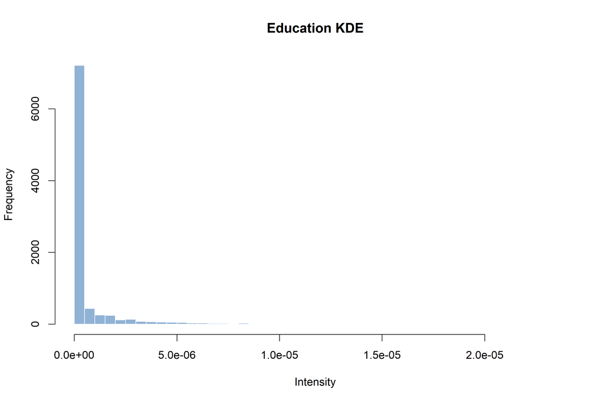

```r
# Shapiro-Wilk requires n <= 5000
sample_idx <- sample(which(valid), min(5000, sum(valid)))

# Plot the histogram to visualize the distribution of intensity values for both categories
hist(education_vals[valid],
     breaks = 50,
     main   = "Education KDE",
     xlab   = "Intensity",
     col    = "#2166ac80",
     border = "white")
```

```r
# Test on raw values of education
shapiro_edu <- shapiro.test(education_vals[sample_idx])
cat("Education KDE:    W =", round(shapiro_edu$statistic, 4), "| p =", shapiro_edu$p.value, "\n")
```

```
Education KDE:    W = 0.3716 | p = 3.614476e-85
```

Since the p-value of the Shapiro-Wilk test is 3.614476e-85, which is significantly less than 0.05, null hypothesis of normality distribution can be rejected. This indicates that the distribution of educational facility intensity across Colombo significantly deviates from normality, suggesting a non-normal distribution.

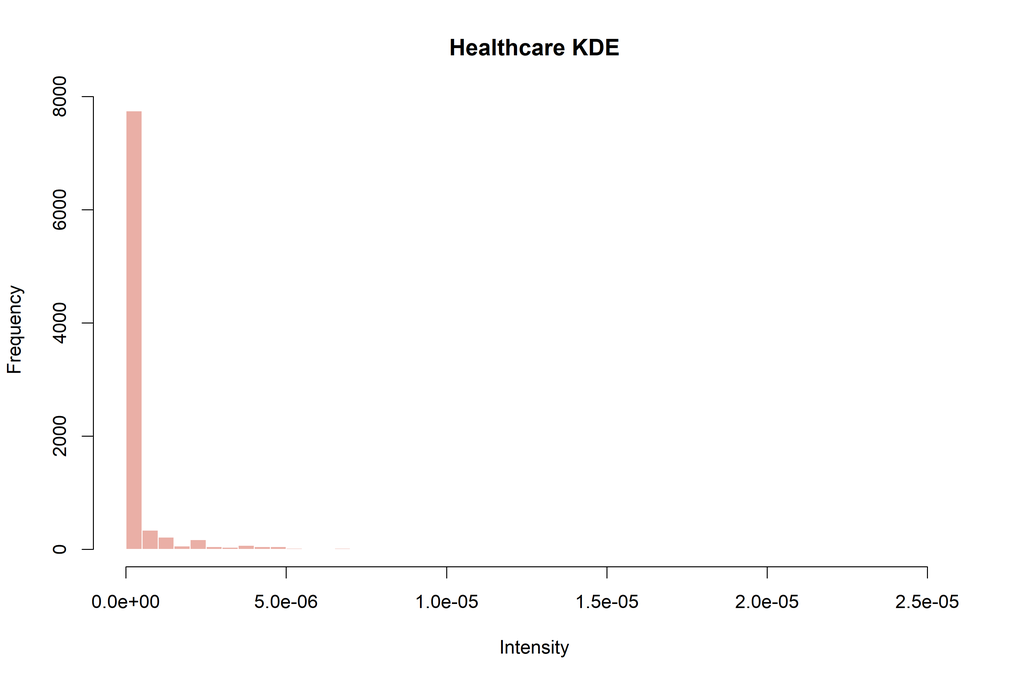

```r
# Plot the histogram
hist(healthcare_vals[valid],
     breaks = 50,
     main   = "Healthcare KDE",
     xlab   = "Intensity",
     col    = "#d6604d80",
     border = "white")
```

```r
# Shapiro Wilk test for the KDE values of healthcare facilities
shapiro_hlth <- shapiro.test(healthcare_vals[sample_idx])
cat("Healthcare KDE:   W =", round(shapiro_hlth$statistic, 4), "| p =", shapiro_hlth$p.value, "\n")
```

```
Healthcare KDE:   W = 0.2859 | p = 4.798521e-88
```

Also the healthcare KDE values have p-value of p = 4.798521e-88, which is significantly less than 0.05, which says that the healthcare facility intensity distribution across Colombo also significantly deviates from normality, indicating a non-normal distribution.

Both educational and healthcare facilities show non-normal distributions in their spatial intensity across the district. Therefore using the Pearson R correlation coefficient to measure the relationship between the two categories may not be appropriate.

## 3.5 Correlation Analysis

Since both educational and healthcare facility intensity distributions are confirmed to be non-normal, Spearman’s rank correlation is used as the primary measure of spatial association. The analysis is conducted at two spatial scales to provide a comprehensive understanding of the relationship between the two amenity types across Colombo.

```r
# Pixel wise KDE Correlation
# Spearman's rank correlation test
spearman_kde <- cor.test(
  education_vals[valid],
  healthcare_vals[valid],
  method = "spearman"
)

# GND wise KDE Correlation
# Spearman's rank correlation test
spearman_gnd <- cor.test(
  gnd_density$education_density,
  gnd_density$healthcare_density,
  method = "spearman"
)

# Summary of the correlation results
cat("  - Pixel wise Spearman Correlation rho:", round(spearman_kde$estimate, 4), "\n")
```

```
  - Pixel wise Spearman Correlation rho: 0.5544
```

```r
cat("  - GND wise Spearman Correlation rho:", round(spearman_gnd$estimate, 4), "\n")
```

```
  - GND wise Spearman Correlation rho: 0.3229
```

[output not shown]

At the pixel level, there is a moderate positive correlation between the intensity of education and healthcare facilities, this reflect that areas with higher concentration of educational facilities also tend to have higher concentration of healthcare facilities as well.